# TASK5：基于中际旭创日度数据的机器学习分类模型开发样例

**姓名**：李明凯 **数据**：中际旭创（300308.SZ）日度交易数据（前复权）

本 Notebook 演示如何把一段股价走势数据，转化为「预测次日涨跌方向」的**有监督机器学习分类问题**，并横向对比多种经典分类模型：

- 逻辑回归、K 近邻、决策树、随机森林、SVM、梯度提升（GBM）+ 多数类基线
- 对每个模型计算 **ROC-AUC**，并为每个模型**单独绘制 ROC 曲线**（单模型网格 + 多模型叠加）
- 严格按时间序列划分训练/测试，杜绝未来函数与数据泄漏

> 结构：理论(Markdown) → 代码 → 可视化 紧贴；中文用 `FontProperties` 指向 `C:\Windows\Fonts\msyh.ttc`；涨红跌绿（A 股惯例）。

```python
%matplotlib inline
import warnings
warnings.filterwarnings('ignore')
import pandas as pd
import numpy as np
import matplotlib.pyplot as plt
from matplotlib.font_manager import FontProperties

# 中文字体（Windows 环境）
chinese_font = FontProperties(fname=r'C:\Windows\Fonts\msyh.ttc', size=12)
chinese_font_title = FontProperties(fname=r'C:\Windows\Fonts\msyh.ttc', size=16)
plt.rcParams['axes.unicode_minus'] = False  # 正常显示负号
print('环境就绪：pandas', pd.__version__, '| numpy', np.__version__)
```

```
环境就绪：pandas 3.0.3 | numpy 2.5.1
```

## 一、环境准备与数据加载

### 1.2 加载数据

读取本地 CSV，将 `trade_date` 由 YYYYMMDD 整数解析为日期并排序，设为索引。

```python
CSV = '中际旭创_日度交易数据.csv'
df = pd.read_csv(CSV)
df['trade_date'] = pd.to_datetime(df['trade_date'].astype(str), format='%Y%m%d')
df = df.sort_values('trade_date').reset_index(drop=True)
df = df.set_index('trade_date')
print('数据形状:', df.shape)
print('时间范围:', df.index.min().date(), '→', df.index.max().date())
display(df.head(5))
display(df.tail(5))
df.info()
```

```
数据形状: (727, 9)
时间范围: 2023-07-04 → 2026-07-03
```

| trade_date | ts_code | open | high | low | close | change | pct_chg | vol | amount |
| --- | --- | --- | --- | --- | --- | --- | --- | --- | --- |
| 2023-07-04 | 300308.SZ | 103.05 | 105.79 | 101.96 | 103.06 | 0.38 | 0.37 | 310201 | 4.580082e+09 |
| 2023-07-05 | 300308.SZ | 102.69 | 103.06 | 97.45 | 97.62 | -5.44 | -5.28 | 341397 | 4.864647e+09 |
| 2023-07-06 | 300308.SZ | 97.49 | 102.37 | 96.72 | 98.23 | 0.61 | 0.62 | 323412 | 4.578612e+09 |
| 2023-07-07 | 300308.SZ | 101.67 | 106.00 | 95.66 | 103.39 | 5.16 | 5.25 | 507938 | 7.325080e+09 |
| 2023-07-10 | 300308.SZ | 102.12 | 103.32 | 96.24 | 100.96 | -2.43 | -2.35 | 419946 | 5.942156e+09 |

| trade_date | ts_code | open | high | low | close | change | pct_chg | vol | amount |
| --- | --- | --- | --- | --- | --- | --- | --- | --- | --- |
| 2026-06-29 | 300308.SZ | 1239.00 | 1264.21 | 1169.49 | 1220.00 | -33.89 | -2.70 | 352899 | 4.263177e+10 |
| 2026-06-30 | 300308.SZ | 1223.01 | 1295.60 | 1218.21 | 1270.00 | 50.00 | 4.10 | 276783 | 3.496056e+10 |
| 2026-07-01 | 300308.SZ | 1263.50 | 1315.57 | 1208.00 | 1223.17 | -46.83 | -3.69 | 271557 | 3.425625e+10 |
| 2026-07-02 | 300308.SZ | 1160.00 | 1198.00 | 1127.40 | 1143.00 | -80.17 | -6.55 | 317620 | 3.672129e+10 |
| 2026-07-03 | 300308.SZ | 1130.00 | 1188.01 | 1115.00 | 1116.00 | -27.00 | -2.36 | 328618 | 3.770236e+10 |

```
<class 'pandas.DataFrame'>
DatetimeIndex: 727 entries, 2023-07-04 to 2026-07-03
Data columns (total 9 columns):
 #   Column   Non-Null Count  Dtype
---  ------   --------------  -----
 0   ts_code  727 non-null    str
 1   open     727 non-null    float64
 2   high     727 non-null    float64
 3   low      727 non-null    float64
 4   close    727 non-null    float64
 5   change   727 non-null    float64
 6   pct_chg  727 non-null    float64
 7   vol      727 non-null    int64
 8   amount   727 non-null    float64
dtypes: float64(7), int64(1), str(1)
memory usage: 56.8 KB
```

### 1.3 数据诊断

检查缺失值、重复行、日期连续性与复权情况（>15% 单日跳空提示未复权）。

```python
# 完整性诊断
n_missing = int(df.isna().sum().sum())
n_dup = int(df.duplicated().sum())
print('缺失值总数:', n_missing, '| 重复行:', n_dup)

# 日期连续性
gap = df.index.to_series().diff().dt.days
print('交易日间隔最大值(天):', int(gap.max()), '（>5 视为存在停牌/缺失）')

# 复权确认：是否存在 >15% 的单日跳空
jump = int((df['close'].pct_change().abs() > 0.15).sum())
print('单日涨幅>15% 的异常跳空天数:', jump, '（若接近 0 说明已前复权）')
print('结论：数据完整、连续，可直接用于建模。')
```

[output not shown]

## 二、机器学习分类理论与概念

### 2.1 监督学习 / 分类问题

给定带标签样本 `(x_i, y_i)`，学习映射 `f: x → y`；分类任务的 `y` 是**离散类别**。 本任务：`x` = 第 t 日及之前派生的因子向量；`y` = 第 t+1 日涨跌方向（0/1）。

### 2.2 标签定义

- **二分类（默认主任务）**：`y_t = 1` 若 `pct_chg_{t+1} > 0`，否则 `y_t = 0`（预测次日是否上涨）。
- **不平衡提示**：上涨/下跌样本可能不均衡，评估不能只看准确率，要看精确率/召回率/F1/ROC-AUC。

### 2.3 特征工程族

- **收益族**：对数收益、N 日累计收益、滞后收益
- **动量/均线族**：均线位置、均线差
- **波动率族**：滚动收益标准差、ATR
- **技术指标族**：RSI、MACD、布林带位置（沿用 task2）
- **成交量族 / 形态族**：量能变化、振幅、收盘区间位置
- 全部特征**只用 t 及之前的信息**，确保无前视。

### 2.4 训练 / 测试划分（避免泄漏）

- **时间序列不能用随机打乱**：股价时序相关，随机切分会让未来信息泄漏进训练集。
- 采用**按时间顺序切分**：前 80% 训练、后 20% 测试。
- 标准化/缩放只 `fit` 于训练集；交叉验证用 `TimeSeriesSplit`。

### 2.5 模型家族对照

| 模型 | 类型 | 特点 |
| --- | --- | --- |
| 逻辑回归 | 线性 | 基线，输出概率，可解释 |
| K 近邻 | 非参数 | 直观，受量纲影响大（必须标准化） |
| 决策树 | 树 | 易解释、易过拟合 |
| 随机森林 | 集成树 | 抗过拟合，可输出特征重要性 |
| SVM | 边界型 | 核技巧，需概率标志才能画 ROC |
| 梯度提升 | 集成树 | 强学习器，通常表现好 |
| 多数类基线 | 参照 | 永远预测多数类，作「地板」对照 |

### 2.6 ROC 曲线与 AUC（重点）

- **ROC 曲线**：以「假正率 FPR」为横轴、「真正率 TPR」为纵轴，遍历不同判定阈值得到；对角线为随机猜测（AUC=0.5）。
- **AUC（曲线下面积）**：单值概括整体判别力，`AUC=0.5` 等于随机，`>0.5` 有判别力，**对类别不平衡稳健**，是分类模型首选综合指标。
- **逐模型要求**：对**每一个**模型都用测试集预测概率计算 AUC，并单独绘制其 ROC 曲线（见第六部分）。

## 三、特征工程（理论 → 代码）

从 OHLCV 原始字段派生 22 个因子，覆盖收益、动量、波动、技术指标、成交量、形态六族。

```python
close = df['close']
high, low, vol, amount = df['high'], df['low'], df['vol'], df['amount']

# 收益族
df['ret'] = np.log(close/close.shift(1))
df['ret_1'] = df['ret'].shift(1)
df['ret_2'] = df['ret'].shift(2)
df['ret_3'] = df['ret'].shift(3)
df['cumret_5']  = close/close.shift(5)  - 1
df['cumret_10'] = close/close.shift(10) - 1
df['cumret_20'] = close/close.shift(20) - 1

# 均线族
for w in [5, 10, 20, 60]:
    df[f'MA{w}'] = close.rolling(w).mean()
df['ma_gap'] = df['MA5'] - df['MA20']
df['mom20']  = close/df['MA20'] - 1
df['mom60']  = close/df['MA60'] - 1

# 波动率族
df['vol20'] = df['ret'].rolling(20).std()
df['vol60'] = df['ret'].rolling(60).std()
prev_close = close.shift(1)
tr = pd.concat([(high-low), (high-prev_close).abs(), (low-prev_close).abs()], axis=1).max(axis=1)
df['ATR14'] = tr.rolling(14).mean()

# 技术指标族（沿用 task2 公式）
delta = close.diff()
gain = delta.clip(lower=0).rolling(14).mean()
loss = (-delta.clip(upper=0)).rolling(14).mean()
rs = gain/loss
df['RSI14'] = 100 - 100/(1+rs)
ema12 = close.ewm(span=12, adjust=False).mean()
ema26 = close.ewm(span=26, adjust=False).mean()
df['MACD'] = ema12 - ema26
df['MACD_signal'] = df['MACD'].ewm(span=9, adjust=False).mean()
df['MACD_hist'] = df['MACD'] - df['MACD_signal']
mid20 = close.rolling(20).mean()
std20 = close.rolling(20).std()
df['BB_pos'] = (close - mid20)/(2*std20)

# 成交量族
df['vol_chg5']    = vol/vol.shift(5) - 1
df['amount_chg5'] = amount/amount.shift(5) - 1

# 形态族
df['range'] = (high-low)/close
df['close_pos'] = (close-low)/(high-low)

features = ['ret','ret_1','ret_2','ret_3','cumret_5','cumret_10','cumret_20',
            'ma_gap','mom20','mom60','vol20','vol60','ATR14',
            'RSI14','MACD','MACD_signal','MACD_hist','BB_pos',
            'vol_chg5','amount_chg5','range','close_pos']
print('派生特征数:', len(features))
```

```
派生特征数: 22
```

### 3.7 特征相关性热力图

检查因子间冗余，避免多重共线性过高（如不同周期均线高度相关）。

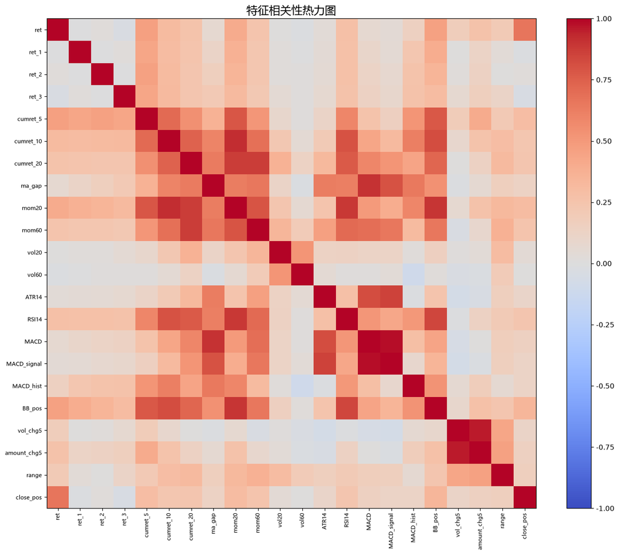

```python
plt.figure(figsize=(13, 11))
corr = X.corr() if 'X' in dir() else df[features].corr()
im = plt.imshow(corr.values, cmap='coolwarm', vmin=-1, vmax=1)
plt.colorbar(im, fraction=0.046)
plt.xticks(range(len(features)), features, rotation=90, fontproperties=chinese_font, fontsize=8)
plt.yticks(range(len(features)), features, fontproperties=chinese_font, fontsize=8)
plt.title('特征相关性热力图', fontproperties=chinese_font_title)
plt.tight_layout()
plt.show()
```

## 四、标签构造与数据划分（严格防泄漏）

- 标签 `y_t` 基于 `pct_chg_{t+1}`（次日信息），特征仅用 `≤ t` 信息 → 无未来函数。
- 时序顺序切分（前 80% 训练 / 后 20% 测试），禁止随机打乱。
- `StandardScaler` 仅 `fit` 于训练集。

```python
# 二分类标签：次日是否上涨（标签用 t+1，特征仅用 <=t，无未来函数）
df['label'] = (df['pct_chg'].shift(-1) > 0).astype(int)

# 去除含 NaN 的行（前 60 行因 MA60/vol60 缺失 + 末行标签缺失）
df = df.dropna(subset=features+['label']).copy()
print('建模样本数:', len(df), '| 上涨占比:', round(df['label'].mean(), 3))

X = df[features]
y = df['label']

# 时序顺序切分（前 80% 训练，后 20% 测试，绝不随机打乱）
split = int(len(df)*0.8)
X_train, X_test = X.iloc[:split], X.iloc[split:]
y_train, y_test = y.iloc[:split], y.iloc[split:]
print(f'训练集: {len(X_train)}  测试集: {len(X_test)}')
print('训练集上涨占比:', round(y_train.mean(), 3), '| 测试集上涨占比:', round(y_test.mean(), 3))

# 标准化：仅 fit 训练集
from sklearn.preprocessing import StandardScaler
scaler = StandardScaler().fit(X_train)
Xtr = scaler.transform(X_train)
Xte = scaler.transform(X_test)
```

```
建模样本数: 667 | 上涨占比: 0.514
训练集: 533  测试集: 134
训练集上涨占比: 0.505 | 测试集上涨占比: 0.552
```

## 五、多模型训练与评估（核心）

用同一套特征训练 7 个模型，对**每一个模型**计算 Accuracy / Precision / Recall / F1 / **ROC-AUC**，并保存 ROC 坐标用于绘图。

```python
from sklearn.linear_model import LogisticRegression
from sklearn.neighbors import KNeighborsClassifier
from sklearn.tree import DecisionTreeClassifier
from sklearn.ensemble import RandomForestClassifier, GradientBoostingClassifier
from sklearn.svm import SVC
from sklearn.dummy import DummyClassifier
from sklearn.metrics import (accuracy_score, precision_score, recall_score,
                             f1_score, roc_auc_score, roc_curve)

models = {
    '逻辑回归':   LogisticRegression(max_iter=1000),
    'K近邻':     KNeighborsClassifier(n_neighbors=5),
    '决策树':     DecisionTreeClassifier(max_depth=5, random_state=42),
    '随机森林':   RandomForestClassifier(n_estimators=200, max_depth=8, random_state=42),
    'SVM':       SVC(probability=True, random_state=42),
    '梯度提升':   GradientBoostingClassifier(random_state=42),
    '多数类基线': DummyClassifier(strategy='most_frequent'),
}

results = []
roc_data = {}
for name, mdl in models.items():
    mdl.fit(Xtr, y_train)
    y_pred = mdl.predict(Xte)
    y_prob = mdl.predict_proba(Xte)[:, 1]
    # 基线概率为常量，AUC 退化为 0.5，ROC 为对角线
    if y_prob.min() == y_prob.max():
        auc = 0.5
        fpr, tpr = np.array([0.0, 1.0]), np.array([0.0, 1.0])
    else:
        fpr, tpr, _ = roc_curve(y_test, y_prob)
        auc = roc_auc_score(y_test, y_prob)
    roc_data[name] = (fpr, tpr, auc)
    results.append({
        '模型': name,
        '准确率': accuracy_score(y_test, y_pred),
        '精确率': precision_score(y_test, y_pred, zero_division=0),
        '召回率': recall_score(y_test, y_pred, zero_division=0),
        'F1': f1_score(y_test, y_pred, zero_division=0),
        'AUC': auc,
    })

res_df = pd.DataFrame(results).sort_values('AUC', ascending=False).reset_index(drop=True)
print('各模型评估完成（按 AUC 降序）：')
```

```
各模型评估完成（按 AUC 降序）：
```

### 5.4 时序交叉验证（TimeSeriesSplit, 5 折）

用 `scoring='roc_auc'` 评估各模型 AUC 的稳定性（基线因常量概率退化为 0.5）。

```python
from sklearn.model_selection import TimeSeriesSplit, cross_val_score
tscv = TimeSeriesSplit(n_splits=5)
cv_rows = []
for name, mdl in models.items():
    try:
        cv = cross_val_score(mdl, Xtr, y_train, cv=tscv, scoring='roc_auc')
        cv_mean, cv_std = cv.mean(), cv.std()
    except Exception:
        cv_mean, cv_std = 0.5, 0.0   # 基线常量概率退化
    cv_rows.append({'模型': name, 'CV_AUC均值': cv_mean, 'CV_AUC_std': cv_std})
cv_df = pd.DataFrame(cv_rows)
res_df = res_df.merge(cv_df, on='模型')
print('时序交叉验证完成')
```

```
时序交叉验证完成
```

### 模型对比汇总表（按 AUC 降序，AUC 列热力着色）

```python
display(res_df.style.format(
    {'准确率':'{:.3f}','精确率':'{:.3f}','召回率':'{:.3f}','F1':'{:.3f}',
     'AUC':'{:.3f}','CV_AUC均值':'{:.3f}','CV_AUC_std':'{:.3f}'}
).background_gradient(subset=['AUC'], cmap='OrRd'))
```

|  | 模型 | 准确率 | 精确率 | 召回率 | F1 | AUC | CV_AUC均值 | CV_AUC_std |
| --- | --- | --- | --- | --- | --- | --- | --- | --- |
| 0 | K近邻 | 0.567 | 0.608 | 0.608 | 0.608 | 0.548 | 0.542 | 0.051 |
| 1 | 梯度提升 | 0.522 | 0.586 | 0.459 | 0.515 | 0.535 | 0.469 | 0.045 |
| 2 | 随机森林 | 0.545 | 0.582 | 0.622 | 0.601 | 0.533 | 0.494 | 0.050 |
| 3 | 多数类基线 | 0.552 | 0.552 | 1.000 | 0.712 | 0.500 | 0.500 | 0.000 |
| 4 | SVM | 0.552 | 0.556 | 0.932 | 0.697 | 0.494 | 0.531 | 0.040 |
| 5 | 逻辑回归 | 0.448 | 0.500 | 0.459 | 0.479 | 0.449 | 0.529 | 0.090 |
| 6 | 决策树 | 0.515 | 0.544 | 0.757 | 0.633 | 0.446 | 0.485 | 0.049 |

## 六、可视化

### 6.2 各模型混淆矩阵（测试集）

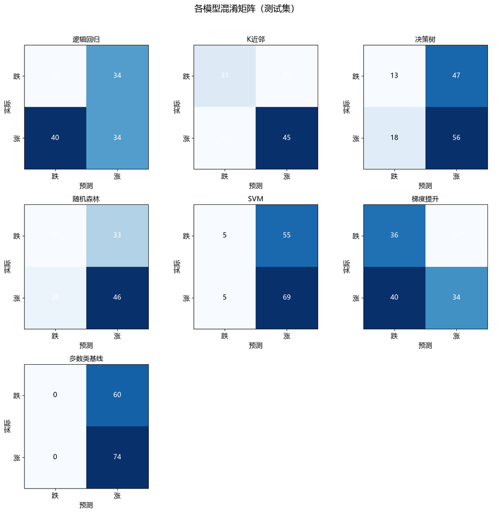

```python
import math
from sklearn.metrics import confusion_matrix
n = len(models); ncols = 3; nrows = math.ceil(n/ncols)
fig, axes = plt.subplots(nrows, ncols, figsize=(13, 4.2*nrows))
axes = axes.ravel()
for i, (name, mdl) in enumerate(models.items()):
    cm = confusion_matrix(y_test, mdl.predict(Xte))
    ax = axes[i]
    ax.imshow(cm, cmap='Blues')
    ax.set_title(name, fontproperties=chinese_font)
    ax.set_xticks([0, 1]); ax.set_yticks([0, 1])
    ax.set_xticklabels(['跌','涨'], fontproperties=chinese_font)
    ax.set_yticklabels(['跌','涨'], fontproperties=chinese_font)
    for (r, c), v in np.ndenumerate(cm):
        ax.text(c, r, v, ha='center', va='center', fontproperties=chinese_font,
                color='white' if v > cm.max()/2 else 'black')
    ax.set_xlabel('预测', fontproperties=chinese_font)
    ax.set_ylabel('实际', fontproperties=chinese_font)
for j in range(n, len(axes)):
    axes[j].axis('off')
plt.suptitle('各模型混淆矩阵（测试集）', fontproperties=chinese_font_title, y=1.02)
plt.tight_layout()
plt.show()
```

### 6.3a 每个模型的 ROC 曲线（独立子图）

**重点要求**：对每一个建立的模型都单独绘制一张 ROC 曲线，并标注其 AUC 值。

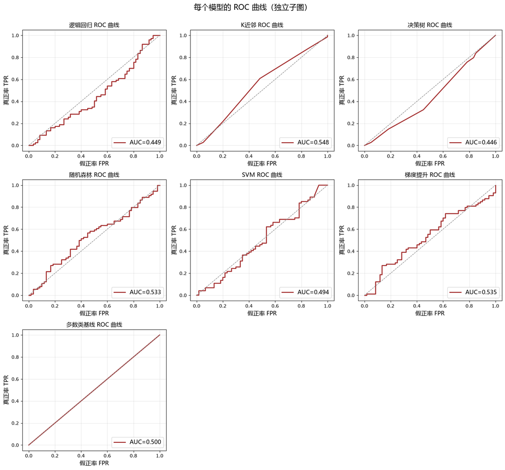

```python
n = len(models); ncols = 3; nrows = math.ceil(n/ncols)
fig, axes = plt.subplots(nrows, ncols, figsize=(15, 4.6*nrows))
axes = axes.ravel()
for i, (name, (fpr, tpr, auc)) in enumerate(roc_data.items()):
    ax = axes[i]
    ax.plot(fpr, tpr, color='#A32D2D', lw=2, label=f'AUC={auc:.3f}')
    ax.plot([0, 1], [0, 1], '--', color='#888888', lw=1)
    ax.set_title(f'{name} ROC 曲线', fontproperties=chinese_font)
    ax.set_xlabel('假正率 FPR', fontproperties=chinese_font)
    ax.set_ylabel('真正率 TPR', fontproperties=chinese_font)
    ax.legend(loc='lower right', prop=chinese_font)
    ax.grid(alpha=0.3)
for j in range(n, len(axes)):
    axes[j].axis('off')
plt.suptitle('每个模型的 ROC 曲线（独立子图）', fontproperties=chinese_font_title, y=1.0)
plt.tight_layout()
plt.show()
```

### 6.3b 多模型 ROC 曲线对比

把所有模型的 ROC 叠加到同一坐标系，按颜色区分并标注各自 AUC，便于横向比较判别力强弱。

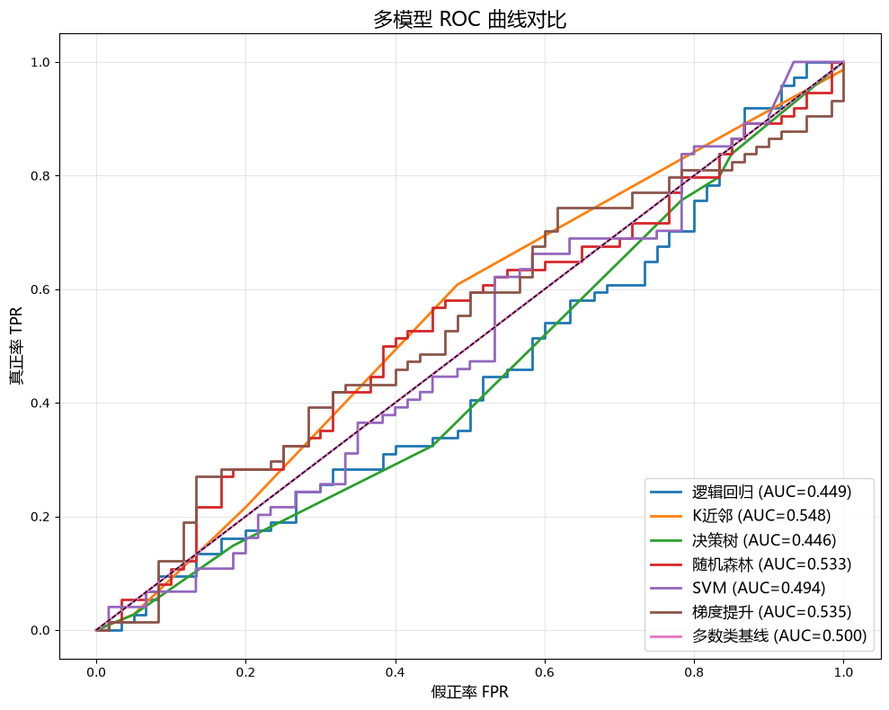

```python
plt.figure(figsize=(10, 8))
cmap = plt.cm.tab10
for k, (name, (fpr, tpr, auc)) in enumerate(roc_data.items()):
    plt.plot(fpr, tpr, color=cmap(k), lw=2, label=f'{name} (AUC={auc:.3f})')
plt.plot([0, 1], [0, 1], 'k--', lw=1)
plt.xlabel('假正率 FPR', fontproperties=chinese_font)
plt.ylabel('真正率 TPR', fontproperties=chinese_font)
plt.title('多模型 ROC 曲线对比', fontproperties=chinese_font_title)
plt.legend(loc='lower right', prop=chinese_font, fontsize=9)
plt.grid(alpha=0.3)
plt.tight_layout()
plt.show()
```

### 6.4 各模型性能指标对比

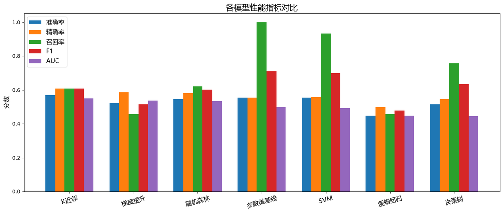

```python
metric_cols = ['准确率','精确率','召回率','F1','AUC']
x = np.arange(len(res_df))
width = 0.15
plt.figure(figsize=(14, 6))
for i, m in enumerate(metric_cols):
    plt.bar(x + (i-2)*width, res_df[m], width, label=m)
plt.xticks(x, res_df['模型'], fontproperties=chinese_font, rotation=15)
plt.ylabel('分数', fontproperties=chinese_font)
plt.title('各模型性能指标对比', fontproperties=chinese_font_title)
plt.legend(prop=chinese_font)
plt.ylim(0, 1.05)
plt.tight_layout()
plt.show()
```

### 6.5 特征重要性（随机森林 / 梯度提升，Top15）

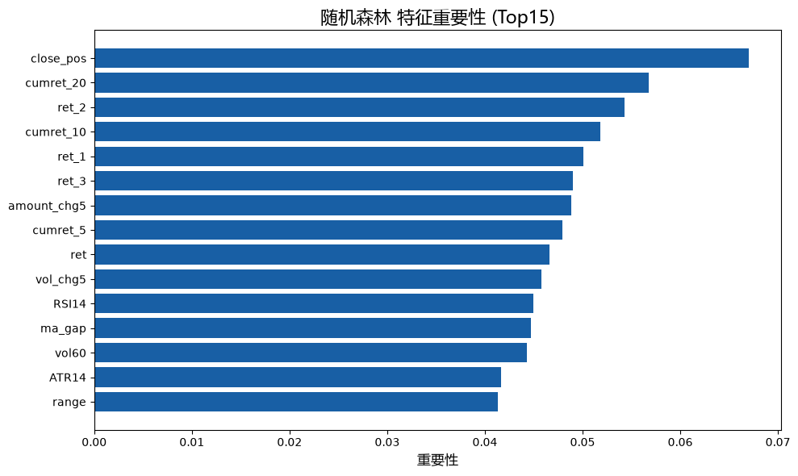

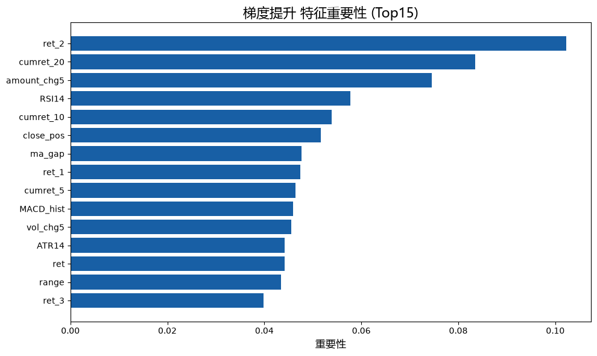

```python
for mdl_name in ['随机森林','梯度提升']:
    mdl = models[mdl_name]
    imp = pd.Series(mdl.feature_importances_, index=features).sort_values(ascending=False).head(15)
    plt.figure(figsize=(10, 6))
    plt.barh(imp.index[::-1], imp.values[::-1], color='#185FA5')
    plt.title(f'{mdl_name} 特征重要性 (Top15)', fontproperties=chinese_font_title)
    plt.xlabel('重要性', fontproperties=chinese_font)
    plt.tight_layout()
    plt.show()
```

### 6.6 决策边界示意（PCA 降维到 2D，仅教学用）

取 2 个主成分，可视化逻辑回归 / KNN / 决策树 / SVM 的决策边界「形状」。

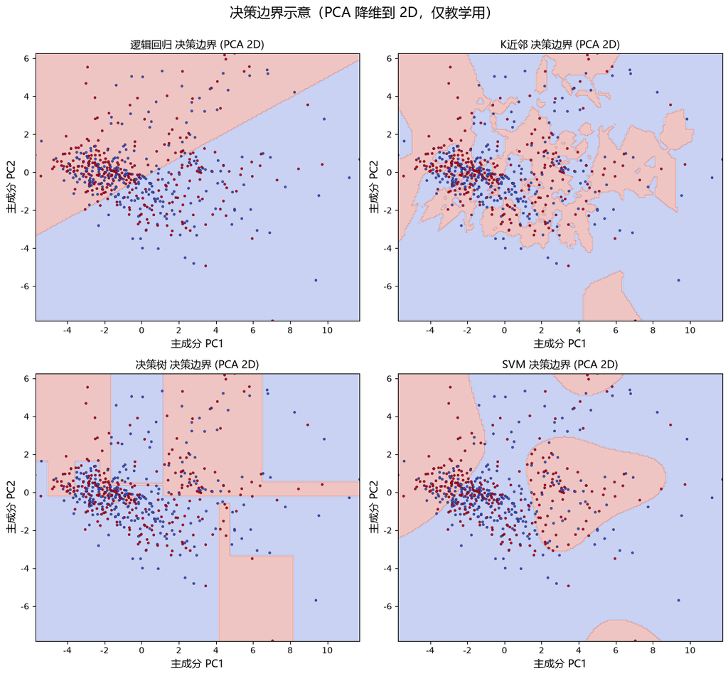

```python
from sklearn.decomposition import PCA
pca = PCA(n_components=2)
Xtr_pca = pca.fit_transform(Xtr)
db_models = {
    '逻辑回归': LogisticRegression(max_iter=1000),
    'K近邻':   KNeighborsClassifier(n_neighbors=5),
    '决策树':   DecisionTreeClassifier(max_depth=5, random_state=42),
    'SVM':     SVC(probability=True, random_state=42),
}
xx, yy = np.meshgrid(np.linspace(Xtr_pca[:,0].min(), Xtr_pca[:,0].max(), 200),
                     np.linspace(Xtr_pca[:,1].min(), Xtr_pca[:,1].max(), 200))
fig, axes = plt.subplots(2, 2, figsize=(12, 11))
axes = axes.ravel()
for i, (nm, mdl) in enumerate(db_models.items()):
    mdl.fit(Xtr_pca, y_train)
    Z = mdl.predict(np.c_[xx.ravel(), yy.ravel()]).reshape(xx.shape)
    ax = axes[i]
    ax.contourf(xx, yy, Z, alpha=0.3, cmap='coolwarm')
    ax.scatter(Xtr_pca[:,0], Xtr_pca[:,1], c=y_train.values, s=8, cmap='coolwarm',
               edgecolor='k', linewidths=0.2)
    ax.set_title(f'{nm} 决策边界 (PCA 2D)', fontproperties=chinese_font)
    ax.set_xlabel('主成分 PC1', fontproperties=chinese_font)
    ax.set_ylabel('主成分 PC2', fontproperties=chinese_font)
plt.suptitle('决策边界示意（PCA 降维到 2D，仅教学用）', fontproperties=chinese_font_title, y=1.0)
plt.tight_layout()
plt.show()
```

### 6.7（可选）方向性策略回测

用 AUC 最高的模型预测信号构造「次日方向性择时」策略，与买入持有对比，说明分类命中率 ≠ 实盘盈利。

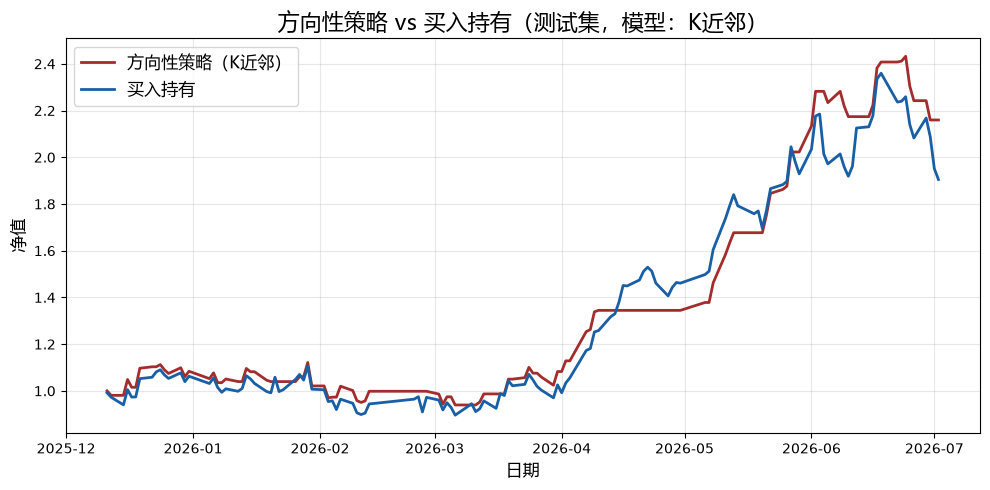

```
策略累计收益: 115.96% | 买入持有累计收益: 90.51%
```

```python
# 用 AUC 最高的模型预测信号，构造"次日方向性择时"策略，与买入持有对比
best = res_df.iloc[0]['模型']
y_pred_best = models[best].predict(Xte)
signal = pd.Series(y_pred_best, index=y_test.index)          # 1=看多持仓, 0=空仓
# 次日实际收益率：用收盘价反推，并剔除最后一行（无次日数据 → NaN）
fwd_ret = (df['close'].shift(-1)/df['close'] - 1).loc[y_test.index]
valid = fwd_ret.notna()
signal, fwd_ret = signal[valid], fwd_ret[valid]
strat_ret = signal * fwd_ret
nav_strat = (1+strat_ret).cumprod()
nav_bh = (1+fwd_ret).cumprod()
plt.figure(figsize=(10, 5))
plt.plot(nav_strat, label=f'方向性策略（{best}）', color='#A32D2D', lw=2)
plt.plot(nav_bh, label='买入持有', color='#185FA5', lw=2)
plt.title(f'方向性策略 vs 买入持有（测试集，模型：{best}）', fontproperties=chinese_font_title)
plt.xlabel('日期', fontproperties=chinese_font)
plt.ylabel('净值', fontproperties=chinese_font)
plt.legend(prop=chinese_font)
plt.grid(alpha=0.3)
plt.tight_layout()
plt.show()
print(f'策略累计收益: {nav_strat.iloc[-1]-1:.2%} | 买入持有累计收益: {nav_bh.iloc[-1]-1:.2%}')
```

## 七、量化评价指标理论（速查）

设测试集样本数 `m`，真实标签 `y_i∈{0,1}`，预测概率 `p_i=P(y=1)`，混淆矩阵元素 `TP, FN, FP, TN`。

1. **准确率 Accuracy** `= (TP+TN)/m` —— 整体正确率；**不平衡时失效**。
2. **精确率 Precision** `= TP/(TP+FP)` —— 预测为「涨」里真正涨的比例。
3. **召回率 Recall** `= TP/(TP+FN)` —— 真正涨的样本里被抓住的比例。
4. **F1 分数** `= 2·Precision·Recall/(Precision+Recall)` —— 精确率与召回率的调和平均。
5. **ROC 曲线**：遍历判定阈值得到 `(FPR, TPR)`，其中 `FPR=FP/(FP+TN)`、`TPR=TP/(TP+FN)=Recall`；对角线 `y=x` 为随机基线（AUC=0.5）。
6. **ROC-AUC**：ROC 曲线下面积；`AUC=0.5` 等于随机，`>0.5` 有判别力；对不平衡稳健，是分类模型**首选综合指标**（本任务对每一个模型都计算并标注）。
7. **混淆矩阵**：`[[TN,FP],[FN,TP]]`，直观看「涨/跌」被分错在何处。
8. **时间序列交叉验证（TimeSeriesSplit）**：按时间先后切折，**只用过去折训练、未来折验证**，杜绝未来信息泄漏；本任务以 `scoring='roc_auc'` 评估稳定性。

## 八、总结与扩展

### 本轮（默认特征 + 二分类 + 80/20 时序切分）结论要点

- 查看上方「模型对比汇总表」与「多模型 ROC 对比图」：AUC 最高者判别力最强；**多数类基线 AUC≈0.5** 表示随机水平，任何显著高于它的模型才具备真实预测力。
- 警惕过拟合：决策树在训练集可能很准，但测试集 AUC 偏低；随机森林 / 梯度提升通常更稳。
- **AUC 高 ≠ 实盘盈利**：方向预测与收益幅度、交易成本是两回事（见 6.7）。

### 扩展方向

- 特征寻优 / 超参调优（`GridSearchCV` 以 `roc_auc` 为 scoring）
- 多分类（涨/平/跌）、滚动 walk-forward 验证
- 加入更多股票做横截面；尝试 XGBoost / LightGBM
- 把预测概率作为择时权重，而非 0/1 硬信号